# Part II - (PISA2012_Analysis)

## by (Naomi Sidi)

## Investigation Overview

The PISA2012_Analysis project aims to analyse the responses of student's from the PISA 2012 test administered by the OECD. The objective of this project is twofold:

1. To find out the top performing countries and their future career choices; and
2. To find out whether a student’s socioeconomic status had an effect on their scores and future career choices.

The following are the key insights from the exploratory visualizations:

1. China-Shanghai is the top Country for all subjects. Japan, Finland, Singapore, Hong Kong- China, Chinese Taipei and Korea also featured among the top 5 countries in Math, Reading and Science.
2. A career in Science was the most popular across the board.
3. The socioeconomic status affects a student's performance.

## Dataset Overview

In 2012, 510 000 students from 65 countries/economies(both member and partner states) took part in the assessment. The dataset has 485490 responses and 635 variables. for this analysis however, focuses on 7 countries that were in the top 5 category for Math, Reading and Science.

This project is a technical requirement for the Data Analysis Nanodegree offered by Udacity.

## Visualization 1: The Top Five Countries in Math, Reading and Science

China-Shanghai is the top Country for all subjects. Singapore and Hong Kong- China were also among the top 5 in all subjects. Japan and Finland were among the top 5 countries in Reading and Science but not Maths- while Chinese Taipei and Korea are in the top 5 countries in Mathematics but not Reading and Science.

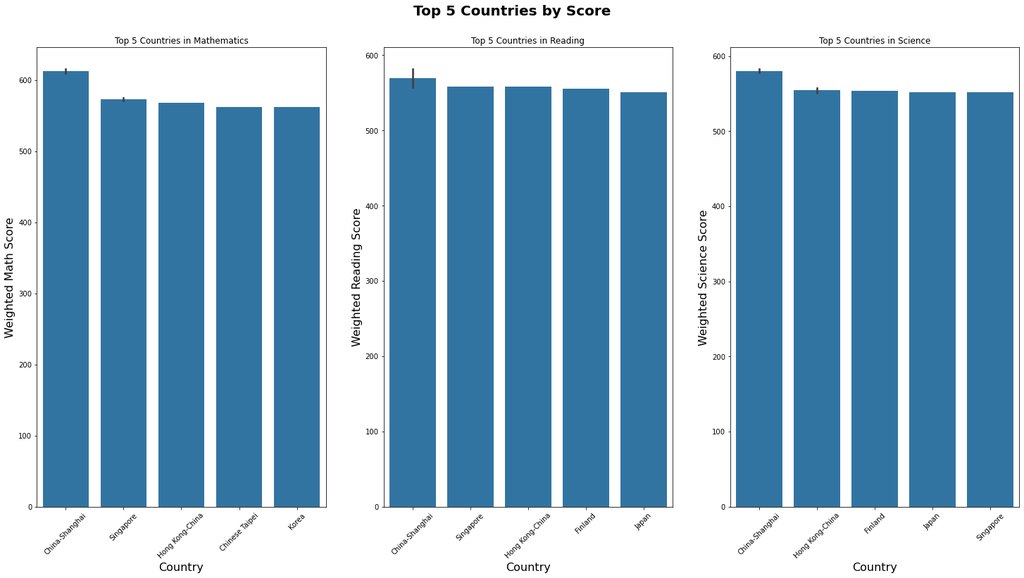

## Visualization 2: The Most Preferred Career Choice

A career in Science is the most preferred for 15 year olds in the top 5 countries. Students in Finland have the highest preference for careers in mathematics even if they do not rank among the first 5 countries in Math Scores, while students from Hong Kong China and China Shanghai scored high in Math but are not very interested in pursuing a career in Math.

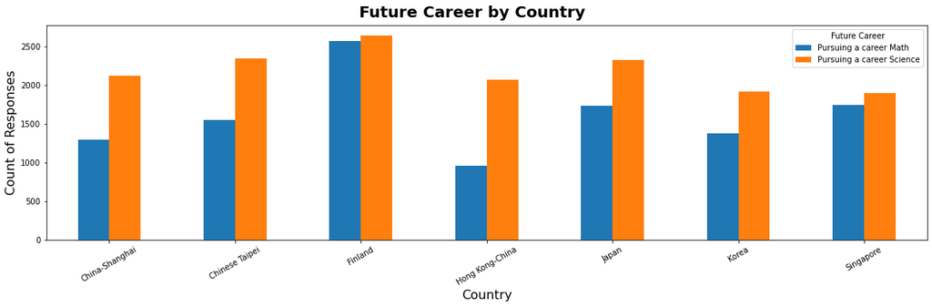

## Visualization 3:The Socioeconomic Status Affects a Student's Perfomance

Students from a low socioeconomic background appeared to lag in achievement in comparison to their counterparts. Students with no bathrooms or computers at home scored lower than their counterparts. In addition, students of low socioeconomic status did not seem to show much preference in their future career path.

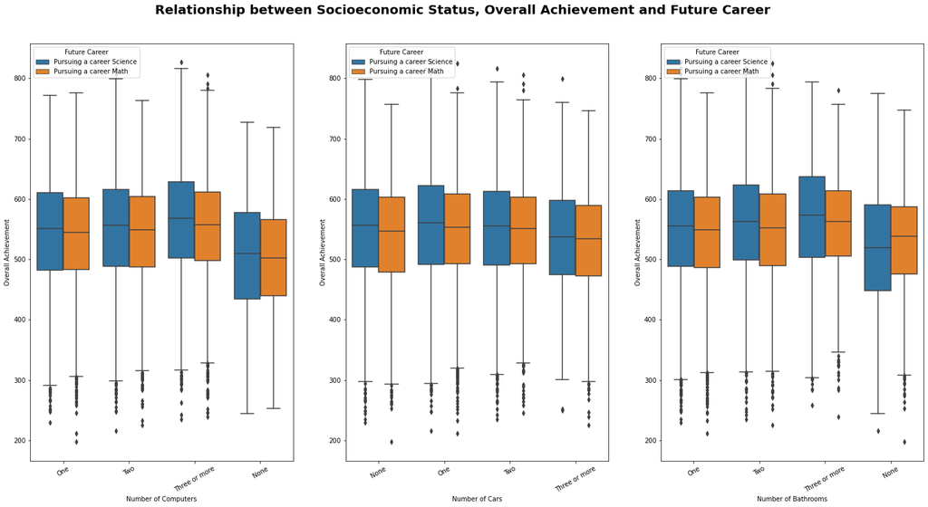